# Reproducible Research Assessment 1

Ingrid Tobar

March 5, 2017

**1. Loading and preprocessing the data**

Code needed to load the data and process/transform the data into a format suitable for analysis.

```r
destfile = "./data/Factivity.zip"
fileURL <- "https://d396qusza40orc.cloudfront.net/repdata%2Fdata%2Factivity.zip"
if(!file.exists(destfile)){download.file(fileURL, destfile, method="auto")}
activityfile <- "./data/activity.csv"
if(!file.exists(activityfile)){unzip(zipfile="./data/Factivity.zip",exdir="./data")}
data <- read.csv(activityfile)
rm(activityfile)
data$date <- as.Date(data$date)
```

## Mean total number of steps per day

What is the mean total number of steps taken per day? For this part of the assignment, ignore the missing values in the dataset.

**2. Make a histogram of the total number of steps taken each day**

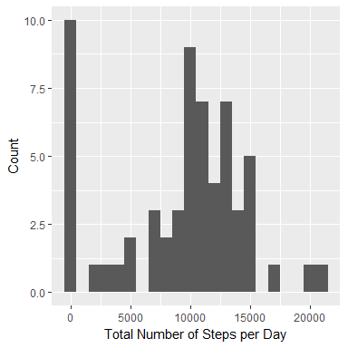

```r
#Histogram in ggplot
library(ggplot2)
total.steps <- tapply(data$steps, data$date, FUN = sum, na.rm = TRUE)
qplot(total.steps, binwidth = 1000, xlab = "Total Number of Steps per Day", ylab = "Count")
```

**3. Calculate and report the mean and median of the total number of steps taken per day**

```r
#Calculate mean and median
meansteps <- as.integer(mean(total.steps, na.rm = TRUE))
mediansteps <- as.integer(median(total.steps, na.rm = TRUE))
print(c("Mean Steps:", meansteps, "Median Steps:", mediansteps))
```

```
## [1] "Mean Steps:"   "9354"          "Median Steps:" "10395"
```

## What is the average daily activity pattern?

Make a time series plot of the 5-minute interval (x-axis) and the average number of steps taken, averaged across all days (y-axis).

```r
##Group data by 5 minute interval and summarize the average number of steps in that interval
averages <- aggregate(steps ~ interval, data, mean)
```

**4. Time series plot of the 5-minute interval and the average number of steps taken, averaged across all days**

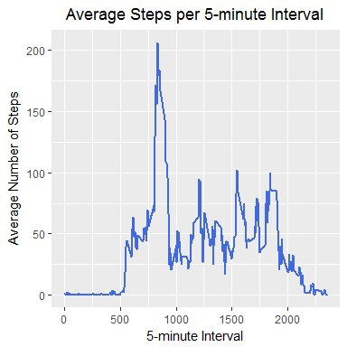

```r
#Average activity plot
p2 <- ggplot(data = averages, aes(x = interval, y = steps)) +
  geom_line(color = "royalblue", size=1) +
  ggtitle("Average Steps per 5-minute Interval") +
  xlab("5-minute Interval") +
  ylab("Average Number of Steps") +
  theme(plot.title = element_text(hjust = 0.5))
print(p2)
```

**5. Which 5-minute interval across all days contains the maximum number of steps?**

```r
maxInt <- averages[which.max(averages$steps),]
print(maxInt)
```

```
##     interval    steps
## 104      835 206.1698
```

## Imputing missing values

Note that there are a number of days/intervals where there are missing values (coded as NA). The presence of missing days may introduce bias into some calculations or summaries of the data.

**Calculate and report the total number of missing values in the dataset (i.e. the total number of rows with NAs)**

```r
missingVals <- is.na(data$steps)
table(missingVals)
```

```
## missingVals
## FALSE  TRUE
## 15264  2304
```

Devise a strategy for filling in all of the missing values in the dataset. Create a new dataset that is equal to the original dataset but with the missing data filled in.

**6. The strategy is to replace missing values with the mean value of their respective 5-minute interval.**

```r
fill.value <- function(steps, interval) {
    filled <- NA
    if (!is.na(steps))
        filled <- c(steps) else filled <- (averages[averages$interval == interval, "steps"])
    return(filled)
}
filled.data <- data
filled.data$steps <- mapply(fill.value, filled.data$steps, filled.data$interval)
```

**7. Make a histogram of the total number of steps taken each day after missing values are imputed**

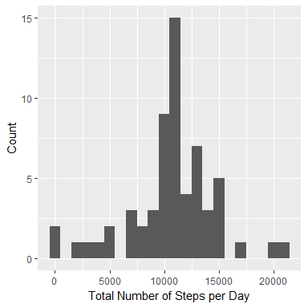

```r
total.steps <- tapply(filled.data$steps, filled.data$date, FUN = sum)
qplot(total.steps, binwidth = 1000, xlab = "Total Number of Steps per Day", ylab = "Count")
```

**Calculate and report the mean and median of the total number of steps taken per day of the new data set with imputed missing data**

```r
#Calculate mean and median
new_mean <- as.integer(mean(total.steps))
new_median <- as.integer(median(total.steps))
print(c("Mean Steps:", new_mean, "Median steps:", new_median))
```

```
## [1] "Mean Steps:"   "10766"         "Median steps:" "10766"
```

The mean calculated after imputing missing data is now closer to the median value. The NAs in the original data are set to zero by default. When these values are replaced with the mean number of steps for their respective interval, the large proportion of zero values observed in the first histogram is removed.

## Are there differences in activity patterns between weekdays and weekends?

Create a new factor variable in the dataset with two levels - “weekday” and “weekend” indicating whether a given date is a weekday or weekend day.

```r
weekday.or.weekend <- function(date) {
    Day <- weekdays(date)
    if (Day %in% c("Monday", "Tuesday", "Wednesday", "Thursday", "Friday"))
        return("Weekday") else if (Day %in% c("Saturday", "Sunday"))
        return("Weekend") else stop("invalid date")
}
filled.data$date <- as.Date(filled.data$date)
filled.data$Day <- sapply(filled.data$date, FUN = weekday.or.weekend)
```

**8. Panel plot comparing the average number of steps taken per 5-minute interval across weekdays and weekends**

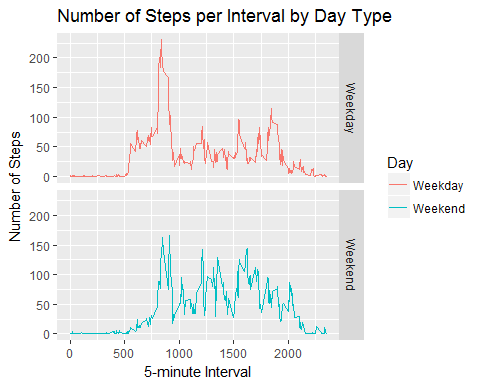

```r
averages <- aggregate(steps ~ interval + Day, data = filled.data, mean)
ggplot(averages, aes(interval, steps)) + geom_line(stat = "identity", aes(colour = Day)) + facet_grid(Day ~ .) +
    xlab("5-minute Interval") + ylab("Number of Steps") + ggtitle("Number of Steps per Interval by Day Type")
```